# Four Iceberg Tools, Three Agent Frameworks: What Ports, and What Doesn't

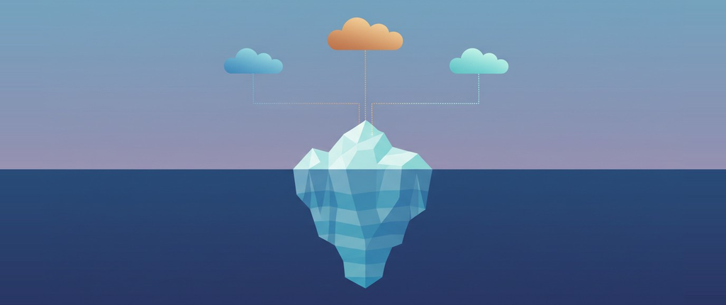

This article is a step by step build of one small Apache Iceberg data agent, written three times: in Google ADK, in AWS Strands and in Microsoft Agent Framework. Each version runs against five Iceberg catalogs.

Every answer is checked against the catalog itself, so the differences between the three agents are measured rather than described.

https://github.com/xbill9/lakehouse-iceberg-2026

#### What Is This Project Trying to Do?

All three hyperscalers now ship their own agent framework. The tables those agents would read are increasingly in Apache Iceberg, an open table format built so that any engine can read the same data. The data is readable from anywhere. Is an agent that reads it portable too?

An [earlier article](https://dev.to/gde/seven-iceberg-rest-catalogs-what-they-declare-and-what-they-serve-40oj) measured the catalog side: seven Iceberg REST catalogs, and the read operations all of them serve. This project measures the agent side. It builds a small data analyst -- list the tables, describe one, count or read its rows, and cite the exact table version it read -- three times:

- **Google** — ADK on `gemini-2.5-flash`, reading BigLake
- **AWS** — Strands on `us.amazon.nova-micro-v1:0`, reading Glue
- **Azure** — Agent Framework on `gpt-5-mini`, reading OneLake

The four tools and the instruction are the same Python objects in all three. Moving this agent between clouds could cost you in three places: the code, the behaviour -- does it answer the same way, as fast -- and the plumbing that reads a catalog's files. Each is measured below, on 2026-09-15 (UTC), ten runs per cell and twenty in Test 5.

#### What Did It Find?

**Building the agent ports; running it does not.** Construction differs by one argument and one keyword. Calling the agent, signing in and reading its answer are three different jobs per framework.

**The framework adds a smaller cost.** On the same Gemini model, Strands was slower than ADK on both questions: 1.52x on the simple one, 10.86s against 7.89s on the data one. It was slower per generated token in both.

**The per-cloud work is the storage wiring.** The tools bind unchanged, but reading a catalog's files needs its own configuration for OneLake, Glue and S3 Tables. Get it wrong and the catalog still answers while the data read fails, with an error naming something else.

**Every agent read its own cloud's Iceberg data, and they all answered alike.** Each leg scanned GCS, S3 or ADLS through its own catalog and cited the exact snapshot. All four setups gave the largest id and the filtered count in all twenty runs. That holds because the scan filters and counts in PyIceberg.

#### What Is Apache Iceberg, and Why Does It Matter?

A lakehouse keeps its data as ordinary files, usually Parquet, in object storage such as S3, GCS or ADLS.

On their own those files are a pile. Nothing says which of them make up a table, which version is current, or what happens when two writers change it at once.

Apache Iceberg answers those questions with a metadata layer over the files: a schema, the list of files in each version, and a chain of immutable snapshots.

- **Many engines, one table.** Spark, Trino, Flink and the cloud warehouses read and write the same table, so the data is not copied into every tool.
- **Versions you can point at.** Every change creates a snapshot, so an answer can name exactly which version it came from. That is what the agents here do.
- **Change without rewrites.** Columns and partitioning can change without rewriting data files.
- **A standard way in.** The REST catalog specification defines one API for finding tables. Google, AWS, Microsoft, Snowflake and Databricks all serve it; the earlier article measured seven implementations.

For developers that means one open API instead of one vendor's warehouse, which is the claim this article tests. Platform admins keep data in their own buckets and govern access at the catalog. Analysts get reads they can reproduce against an exact snapshot.

Deeper dives: the [table specification](https://iceberg.apache.org/spec/), the [REST catalog specification](https://iceberg.apache.org/rest-catalog-spec/) and its [OpenAPI definition](https://github.com/apache/iceberg/blob/main/open-api/rest-catalog-open-api.yaml), and [PyIceberg](https://py.iceberg.apache.org/), the Python library these tools use.

#### What Is Apache Polaris, and Why Is It Here?

Apache Polaris is an open-source implementation of the Iceberg REST catalog. It runs locally in Docker here, holding the same 11-row test table as three of the four managed catalogs.

It is the **control**: the catalog every agent meets before any cloud is involved. A failure against Polaris rules out the vendor. It does not rule out the model.

It cannot test storage wiring, because Polaris keeps its table as local files. See the [Polaris site](https://polaris.apache.org/), [documentation](https://polaris.apache.org/docs/) and [source](https://github.com/apache/polaris).

#### How the Tests Work

Each test changes one thing and holds the rest still:

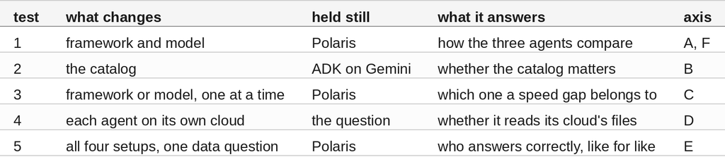

**Ten runs per cell, twenty in Test 5**, in shuffled rounds from a fixed seed, so a slow patch on an endpoint lands across cells. Separation is judged on the middle half of each cell's runs. No run failed to answer.

**Every time is warm answer time.** Each run imports its framework, builds the agent, signs in, and sends one untimed warm-up turn before the clock starts.

That excludes 0.78 / 0.45 / 0.24 seconds of import for ADK / Strands / Agent Framework. It also excludes the first sign-in: 1.25 to 1.53 seconds on Azure, 0.52 to 0.54 on Vertex AI, 0.06 on AWS.

A long-running agent pays those once. A serverless agent that scales to zero pays them on every cold start.

**Tokens and model calls are recorded per answer.** Frameworks report reasoning differently, so comparisons use tokens generated: output plus reasoning.

**Every answer is scored against ground truth read straight from the catalog.** Scoring reads the answer text alone. The row count must sit beside "rows", each column must appear as a whole word, and the snapshot id and metadata location must match exactly.

Two rules keep that honest. An answer is scored on the last count or largest id it states, so a right number on the way to a wrong one fails. And the scorer must fail planted answers before anything publishes: empty ones, swapped ones, and real phrasings it once got wrong.

#### Test 1: The Three Agents, Side by Side

Three legs, Polaris, ten runs each. The models are not matched: Bedrock lists Nova Micro as text in, text out, where Nova Lite and Pro also take images and video.

Gemini and `gpt-5-mini` ran at their defaults. Nova Micro ran with the greedy decoding Amazon [recommends for Nova tool use](https://docs.aws.amazon.com/nova/latest/userguide/prompting-tool-troubleshooting.html), temperature 0 and topK 1.

That decoding is deterministic, which matters for every Nova cell here. The runs in a cell return one answer, word for word, so a Nova score is one answer repeated. Its timings are still real measurements.

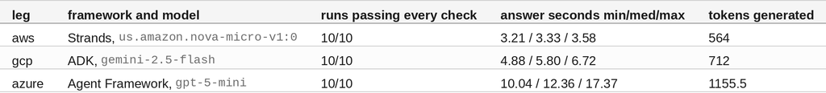

All three answer with the same three calls -- list, describe, count. The spread is 3.72x at the median, and the middle halves do not touch: AWS's upper quartile (3.38s) sits below Google's lower (5.37s), and Google's upper (6.18s) below Azure's lower (11.59s). Tool time is 0.12 seconds, about 2% of an answer.

Against a managed catalog every leg would add tool time (Test 2), which narrows the ratio; these figures are specific to a local catalog.

#### Test 2: Same Agent, Five Catalogs

ADK on Gemini against five catalogs, ten runs each. Every run passed every check.

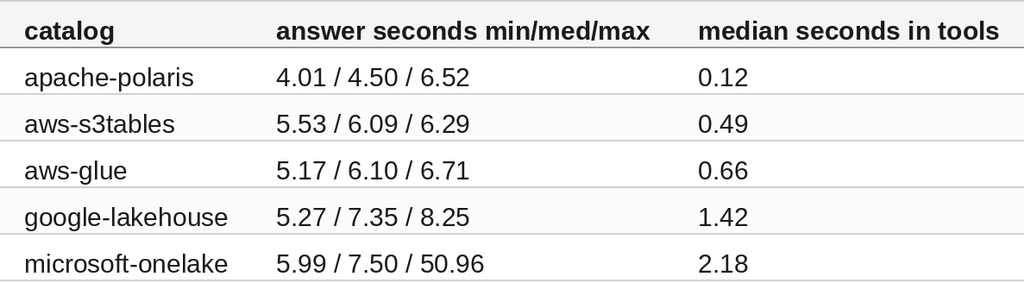

The catalog shows up in the tool column: 0.12 seconds against Polaris, 0.49 to 2.18 against the managed four.

In total answer time, BigLake (7.35 seconds) and OneLake (7.50) sit clearly above Polaris (4.50). S3 Tables (6.09) and Glue (6.10) clear it by little more than the 1.30-second noise, so treat those two as close.

The slowest run, 50.96 seconds on OneLake, spent 44.88 of them in the tools. That is distance from this machine as much as the service, and not a ranking. OneLake's table holds 6 rows and 3 columns; each answer is scored against its own catalog.

#### Test 3: Framework or Model?

Strands, unchanged except for its model object, runs `gemini-2.5-flash` through Vertex AI beside ADK on the same model and endpoint, and beside itself on Nova Micro. All thirty runs passed every check.

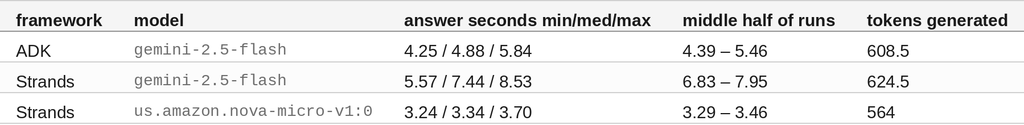

**Swapping the model** under Strands moved the median 2.23x, with no overlap. That comparison also changes provider and region, Vertex AI in `us-central1` against Bedrock in `us-east-1`.

**Swapping the framework** under Gemini moved it 1.52x (2.55 seconds), with no overlap, and it clears the 1.30-second noise. Strands generated 624.5 tokens to ADK's 608.5 and made no more model calls.

Agent Framework ran only `gpt-5-mini`, so its figures describe that pairing. In [an earlier build](https://dev.to/gde/three-clouds-one-brief-what-actually-differs-between-adk-strands-and-agent-framework-2kgc), its `store=False` setting made a non-reasoning model fail; that was not re-tested.

#### Test 4: Each Agent Reads Its Own Cloud's Data

Tests 1 to 3 ask what the catalog's metadata already knows. This one does not: each agent is asked for the largest id, the number of rows with an id of 10 or more, and the table version it read.

Counts come from snapshot summaries and columns from the schema; neither holds a filtered count. Answering means reading the data files -- GCS, S3 or ADLS -- through each cloud's storage wiring.

The scan takes a row filter such as `id >= 10`, applies it in PyIceberg, and returns an exact count with the minimum and maximum over every matching row.

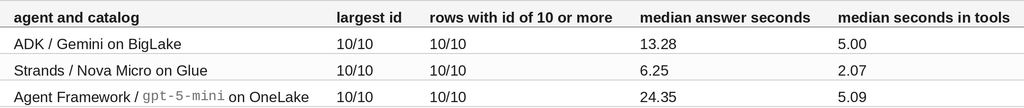

Every agent read its data: the tools print each call they receive, whatever the framework, and every one of the thirty captures shows a scan with a filter.

Glue's 2.07 seconds in the tools is the lowest of the three, and that is the read path rather than the agent: in Test 2, where the catalog is the only thing that changes, Glue costs 0.66 seconds against BigLake's 1.42 and OneLake's 2.18.

These cells are not like for like -- different catalogs, regions, and a smaller OneLake table -- so correctness is compared in Test 5.

#### Test 5: The Same Data Question, Like for Like

All four setups, the same 11-row Polaris table, twenty runs each. The scan applies the filter in PyIceberg and returns the exact count, so no model does arithmetic over rows.

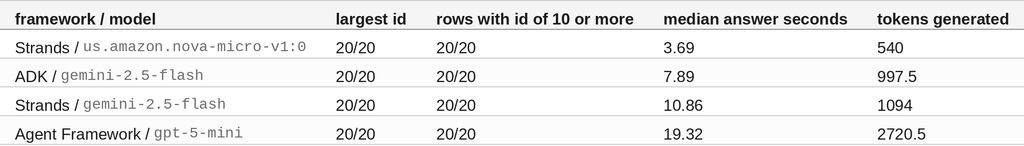

Every capture records the tool calls, so which scan each answer used is on record: all eighty runs above filtered, and every answer quoted the count the scan returned.

**Design the tool so the engine answers.** Rerun the same twenty runs with a scan that returns rows and no count, and the answers stop agreeing. Gemini under both frameworks and `gpt-5-mini` still counted correctly 20 of 20. Nova Micro got none right under greedy decoding -- one wrong answer, repeated -- and 4 of 20 at Bedrock's defaults.

Counting by reading cannot scale anyway, since the scan returns at most 100 rows. A filter and an exact count belong in PyIceberg, whatever model is driving. `nova-diagnosis.txt` has the runs behind that.

**The framework cost shows again, smaller.** On the same model and the same scan, Strands took 10.86 seconds at the median against ADK's 7.89. That clears the 1.30-second noise.

Per 100 generated tokens it was 0.99 seconds against 0.79, slower per token as in Test 3.

#### How Are the Three Agents Different?

The instruction is one string; the four tools are async Python functions with typed arguments and docstrings; the budget of eight catalog calls lives inside the tools. None of that changed. Everything around it did.

**Building it** differs by one argument. ADK takes a model id string, Strands a model object, Agent Framework a chat client holding an endpoint and credential. The instruction is `instruction`, `system_prompt` or `instructions`.

Two traps live here. Strands wants each tool wrapped in `tool()`. ADK re-resolves a bare model id to a new client on every run, so resolve it once and the client, and its token, stay alive.

**Running it** is three different jobs. ADK needs a runner, a session and a loop over events. Strands is called like a function, and keeps the conversation until `agent.messages` is cleared. Agent Framework is awaited.

**Signing in** uses Application Default Credentials for ADK, the boto chain for Strands and `DefaultAzureCredential` for Agent Framework. Azure's first sign-in is the slowest of the three. Strands needs `botocore[crt]` after `aws login`, though the CLI works without it.

**Reading the answer** is where a data agent quietly misleads the code around it. Four questions matter, and the frameworks answer them differently:

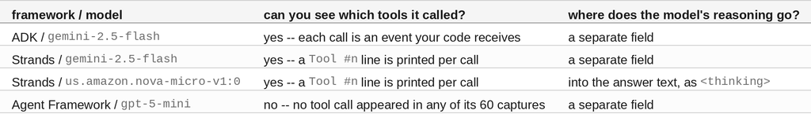

That held in every captured run: all 120 ADK runs, all 180 Strands runs and all 60 Agent Framework runs. Only one model puts reasoning where a caller will read it, so the harness strips `<thinking>` on every leg and the answers below are what a caller receives.

- **Log the tool calls yourself.** ADK and Strands report each call; Agent Framework reported none in any of its 60 runs. The tools here print every call they receive, so the audit trail works the same on all three.
- **Strip reasoning before anything reads the answer.** Nova Micro writes its scratch work as `<thinking>` text, and Strands passes text through. Gemini's and `gpt-5-mini`'s reasoning never reaches the answer. Left in, it leaks the agent's instruction and figures the model discarded. This harness strips it on every leg.
- **Take the whole turn, not the last message.** Strands' `result.message` holds only the final message, and Nova Micro puts part of its answer beside a tool call. Collect every assistant message; ADK and Agent Framework already do.
- **Join text blocks with nothing between them.** Strands' `str(result)` inserts a line break after each block. That split "23" into "2" and "3" in three of ten Gemini answers: a right answer that reads as wrong.

Strands also streams every answer to the terminal, so code that prints the result shows it twice; `callback_handler=None` turns that off.

#### Storage Wiring Per Catalog

Signing the catalog calls and reading the files it points at need different configuration. That configuration lives inside the tool, written once per catalog: `FsspecFileIO` and an account host for OneLake, local credentials for Glue, vended credentials for S3 Tables' managed bucket.

It differs even between two catalogs on the same cloud. Here are three wrong configurations, each with the catalog call succeeding immediately before the data call fails:

```
$ # A. OneLake, no ADLS configuration at all (PyArrowFileIO, no adls.* properties)
CATALOG ERROR while scanning dbo.probe_table: TypeError: __init__() takes exactly 1 positional argument (0 given).

$ # B. OneLake, ADLS credential set but PyArrowFileIO instead of fsspec
CATALOG ERROR while scanning dbo.probe_table: OSError: GetProperties failed for
'https://onelake.blob.core.windows.net/...' Cannot initialise an ObjectInp.

$ # C. Glue, SigV4 for the catalog but no local S3 credentials
CATALOG ERROR while scanning probe_ns.probe_table: OSError: ... AWS Error
ACCESS_DENIED during HeadObject operation
```

B builds a hostname that does not exist, because PyArrow ignores `adls.account-host`; C is `ACCESS_DENIED` on a bucket the caller owns, because pyiceberg used the catalog's vended credentials. None of the three errors names the missing setting. An agent that reads Iceberg is portable at the catalog; at the files, it is configured.

#### How Does This Compare to Other Work?

A September 2026 search found related work on each side, and none that builds the same agent in the three hyperscalers' frameworks, reads several Iceberg REST catalogs, and scores answers against ground truth.

- **Framework benchmarks.** [LaunchDarkly](https://launchdarkly.com/docs/tutorials/agent-graph-experiments) ran LangGraph, Strands, the OpenAI Agents SDK and ADK on one agent graph, model pinned, 36 runs, judged by an LLM. Strands came out fastest, most differences "within a few percent". Here Strands was the slower of the two on both questions. Both results put framework cost well below model cost.
- **Data-agent benchmarks.** [DAB](https://arxiv.org/abs/2603.20576), [FDABench](https://arxiv.org/abs/2509.02473) and [KramaBench](https://arxiv.org/abs/2506.06541) score answers over databases and data lakes. DAB's best model reached 38% pass@1. They vary model and task; this keeps the task simple and varies framework and catalog.
- **Agent latency.** [Bian et al.](https://arxiv.org/abs/2510.16276) found environment latency up to 53.7% of the total in web agents. Catalog time here was about 2% locally, and more against managed catalogs. That is why it is recorded separately.
- **Agents over Iceberg.** There is an [AWS Labs MCP server for S3 Tables](https://github.com/awslabs/mcp/tree/main/src/s3-tables-mcp-server), [MCP-over-Iceberg patterns](https://iceberglakehouse.com/iceberg/iceberg-mcp/) and a [multi-cloud lakehouse architecture](https://aws.amazon.com/blogs/big-data/multi-cloud-lakehouse-architecture-on-aws-for-agentic-ai-part-1-architecture-and-best-practices/). None publish correctness or latency measurements.

This builds on the [catalog side](https://dev.to/gde/seven-iceberg-rest-catalogs-what-they-declare-and-what-they-serve-40oj) and the [framework side](https://dev.to/gde/three-clouds-one-brief-what-actually-differs-between-adk-strands-and-agent-framework-2kgc).

#### Where Do I Start?

The strategy for building a portable Iceberg agent is an incremental step by step approach. First, the environment is set up and Polaris is brought up. Then each leg answers one question against Polaris, ground truth is captured, the tests run, and the evidence is published. Full detail is in [`iceberg-agent/README.md`](https://github.com/xbill9/lakehouse-iceberg-2026/blob/main/iceberg-agent/README.md).

#### Build It Yourself

You need Python 3.14, Docker, Vertex AI on a Google Cloud project, Bedrock access to Nova Micro in `us-east-1`, and a Foundry project with a `gpt-5-mini` deployment. The managed catalogs are optional; the earlier article brings each one up.

```
$ git clone https://github.com/xbill9/lakehouse-iceberg-2026
$ cd lakehouse-iceberg-2026/iceberg-agent
$ python3 -m venv .venv && . .venv/bin/activate
$ pip install -r ../iceberg-conformance/requirements.txt -r requirements.txt
$ (cd ../iceberg-conformance && cp catalogs.example.yaml catalogs.yaml && ./polaris-up.sh)
$ export PYTHONPATH=../iceberg-conformance ICEBERG_CATALOGS_FILE=../iceberg-conformance/catalogs.yaml
$ export POLARIS_CLIENT_ID=root POLARIS_CLIENT_SECRET=s3cr3t AWS_REGION=us-east-1
$ export GOOGLE_GENAI_USE_VERTEXAI=true GOOGLE_CLOUD_LOCATION=us-central1 GOOGLE_CLOUD_PROJECT=<your-project>
$ export FOUNDRY_PROJECT_ENDPOINT=https://<resource>.services.ai.azure.com/api/projects/<project>
```

The README shows how to find the Foundry project endpoint from the Azure management API.

Two things fail quietly here. Install `agent-framework-core` and `agent-framework-foundry`, not the `agent-framework` meta package, which failed to resolve after 1,445 seconds.

Install `adlfs` as well. Without it every OneLake metadata call works and every scan fails.

Ask one leg against Polaris before any cloud:

```
$ python3 run_once.py gcp --catalog apache-polaris --warm "How many rows are in the probe table?"
   -> tool: iceberg_list_tables()
   -> tool: iceberg_describe_table(table='probe_ns.probe_table')
   -> tool: iceberg_count_rows(table='probe_ns.probe_table')

<!-- cloud=gcp model=gemini-2.5-flash catalog=apache-polaris instruction=v3 catalog_calls=3 -->
The `probe_ns.probe_table` contains 11 rows. This figure is from snapshot-id 5653331815319537848, found at metadata-location file:/.../metadata/00006-57dbb327-b002-43cc-9ed3-93e61cab024e.metadata.json.

catalog calls: 3 of 8
agent seconds: 5.08 | tool seconds: 0.12
tokens: input=4660 output=161 reasoning=353 model_calls=4
warm-up seconds: 2.57
```

`--warm` sends one untimed turn first, so sign-in is not in `agent seconds`.

The header stamps cloud, model, catalog, instruction version and call count, so an answer from an older instruction, or an agent that never called its tools, stands out. Then capture ground truth, run the tests and publish:

```
$ python3 capture_ground_truth.py
$ for t in A B C D E F; do python3 run_matrix.py --axis $t --repeat 10; done
$ python3 capture_runs.py && python3 failure_modes.py && python3 nova_diagnosis.py
$ python3 publish_evidence.py && (cd .. && ./check-no-identifiers.sh)
```

`publish_evidence.py` re-scores every capture from its own text. It refuses to publish if that disagrees with the runner, or if the scorer mis-scores a planted answer: empty, swapped, right and then changed, or a real phrasing it once got wrong.

It also maps account identifiers to pseudonyms. Every figure in this article comes from the files it writes.

#### Summary

The question was whether a read-only Apache Iceberg agent ports across frameworks and catalogs. One implementation of four tools went into three frameworks unchanged, and five tests each moved one thing.

Scope:

- One machine, 2026-09-15. 360 timed runs, warm, in shuffled rounds. Enough to see separation, not to estimate rates precisely.
- Every model ran at its defaults except Nova Micro, which used Amazon's recommended tool-use decoding. That decoding is deterministic, so a Nova cell returns one answer in every run: its correctness is one sample, its timings are many.
- Axis F runs Test 1's question with and without that decoding. Test 5's rows-only figures are also given at Bedrock's defaults, where twenty runs are twenty answers.
- Agent Framework ran only `gpt-5-mini`. The model comparison in Test 3 also changes provider and region.
- Polaris is local and the managed catalogs sit in different regions, so no time here compares clouds.
- Timings exclude imports and first sign-in. Cost was not measured.
- Earlier runs are published under `evidence/superseded-runs/`, re-scored by the same checks.

#### How Portable Is It, Really?

Four things move when this agent changes cloud. Two of them are free.

- **The tools and the instruction port.** They were the same Python objects in all three frameworks. Nothing in them is vendor-specific.
- **The code around them does not.** Building the agent differs by a model id, a model object or a chat client. Calling it, signing in and reading its answer are three different jobs. Budget hours, not days.
- **The storage wiring does not, and it costs the most.** Each cloud needs its own file configuration under the same tool. Get it wrong and the catalog still answers while the data read fails, with an error naming something else.
- **Correctness follows the tool, not the cloud.** Put the filter and the count in PyIceberg and every setup here answered alike. Leave that work to the model and the smallest one fails.

The catalog layer really is portable. The work is in what sits around it.

The strategy for using one shared set of Iceberg tools across three agent frameworks was validated with an incremental step by step approach.